# Can we predict one’s biological age?

Multiple linear regression

Joao Malato

Nuno Sepulveda

September 16th, 2022

# Libraries

```r
library(here)       # easy directory management, as here("YOUR/FILE/PATH")
library(data.table) # fast data wrangling
library(magrittr)   # use of pipe operator `%>%`
library(ggplot2)    # graphics
library(nortest)    # normality assessment test
library(MASS)       # stepwise regression
```

# Load data

Still using the same subset of whole blood data from 656 human individuals, made available by [Hannun et al. (2013)](https://www.sciencedirect.com/science/article/pii/S1097276512008933?via%3Dihub).

```r
# base R
# mdna <- read.csv(here("data/methDNA_data_Hannun_etal_2013.csv"), header = TRUE)
mdna_logodds <- read.csv(here("data/logodds_methDNA_data_Hannun_etal_2013.csv"), header = TRUE)
```

```r
# look at first 8 cols from the data
head(mdna_logodds[, 1:8])
```

```
##      GEO.ID Age Gender Ethnicity cg17568996 cg02245378 cg14093936 cg15642326
## 1 GSM989827  67      F Caucasian  -2.422868  -2.319565 -0.7094626 -1.0117542
## 2 GSM989828  89      F Caucasian  -2.698340  -2.202109 -0.9977517 -1.0850560
## 3 GSM989829  66      F Caucasian  -1.984273  -2.164124 -0.7462700 -1.1361828
## 4 GSM989830  64      F Caucasian  -2.228179  -2.315447 -0.6371883 -0.9794073
## 5 GSM989831  62      F Caucasian  -1.969918  -2.246539 -0.6202693 -0.9264593
## 6 GSM989832  87      F Caucasian  -1.388692  -1.632925 -0.5858540 -1.3271837
```

Variables:

```r
# binary variables to factors with defined reference
mdna_logodds$Gender <- relevel(factor(mdna_logodds$Gender), ref = "F")
mdna_logodds$Ethnicity <- relevel(factor(mdna_logodds$Ethnicity), ref = "Caucasian")
```

```r
# get a vector with all column names with their pattern starting with "cg" (i.e., the names of all CpG probes)
vec_probe <- grep("^cg", colnames(mdna_logodds), value = TRUE)

# ordered by correlation with age
vec_cor_values <- sapply(seq(vec_probe), function(x) cor(mdna_logodds$Age, mdna_logodds[, vec_probe[x]], method = "spearman"))
# save the CpG probes ordered by their absolute correlation value
vec_probe_cor <- vec_probe[order(abs(vec_cor_values), decreasing = TRUE)]
```

# Questions

1. Main question: Can we predict one’s biological age?
2. What if we want to add more variables to our model?
3. Which markers should be added? More than one? All of them? Which ones?
4. Is gender significant in out model?
5. Is the participants’ ethnic group significant in out model?
6. What makes a good/better model?

# **Exercise 1:** Which coefficients to add?

```r
# first 5 CpGs in the data:
# cg17568996 + cg02245378 + cg14093936 + cg15642326 + cg24991452

# fit the model
fit5 <- lm(Age ~ cg17568996 + cg02245378 + cg14093936 + cg15642326 + cg24991452, data = mdna_logodds)

# summary
summary(fit5)
```

```
##
## Call:
## lm(formula = Age ~ cg17568996 + cg02245378 + cg14093936 + cg15642326 +
##     cg24991452, data = mdna_logodds)
##
## Residuals:
##     Min      1Q  Median      3Q     Max
## -35.863  -7.922   0.806   8.321  38.672
##
## Coefficients:
##             Estimate Std. Error t value Pr(>|t|)
## (Intercept)   37.105      7.020   5.285 1.71e-07 ***
## cg17568996     4.411      1.874   2.354   0.0189 *
## cg02245378    14.404      2.445   5.892 6.13e-09 ***
## cg14093936   -43.107      3.626 -11.890  < 2e-16 ***
## cg15642326    -3.767      2.516  -1.497   0.1349
## cg24991452   -10.922      1.624  -6.726 3.82e-11 ***
## ---
## Signif. codes:  0 '***' 0.001 '**' 0.01 '*' 0.05 '.' 0.1 ' ' 1
##
## Residual standard error: 12.22 on 650 degrees of freedom
## Multiple R-squared:  0.3173, Adjusted R-squared:  0.312
## F-statistic: 60.42 on 5 and 650 DF,  p-value: < 2.2e-16
```

```r
# top 5 correlated CpGs (decreasing order):
# cg22736354 + cg15804973 + cg06493994 + cg08090640 + cg09809672

# fit the models
fit5_cor <- lm(Age ~ cg22736354 + cg15804973 + cg06493994 + cg08090640 + cg09809672, data = mdna_logodds)

# summary
summary(fit5_cor)
```

```
##
## Call:
## lm(formula = Age ~ cg22736354 + cg15804973 + cg06493994 + cg08090640 +
##     cg09809672, data = mdna_logodds)
##
## Residuals:
##     Min      1Q  Median      3Q     Max
## -27.718  -4.861  -0.051   5.169  37.824
##
## Coefficients:
##             Estimate Std. Error t value Pr(>|t|)
## (Intercept)   98.009      2.614  37.499  < 2e-16 ***
## cg22736354    21.900      2.094  10.456  < 2e-16 ***
## cg15804973   -10.189      1.243  -8.200 1.29e-15 ***
## cg06493994    24.977      2.207  11.317  < 2e-16 ***
## cg08090640    -6.651      1.670  -3.983 7.58e-05 ***
## cg09809672   -12.455      1.347  -9.245  < 2e-16 ***
## ---
## Signif. codes:  0 '***' 0.001 '**' 0.01 '*' 0.05 '.' 0.1 ' ' 1
##
## Residual standard error: 8 on 650 degrees of freedom
## Multiple R-squared:  0.7076, Adjusted R-squared:  0.7053
## F-statistic: 314.5 on 5 and 650 DF,  p-value: < 2.2e-16
```

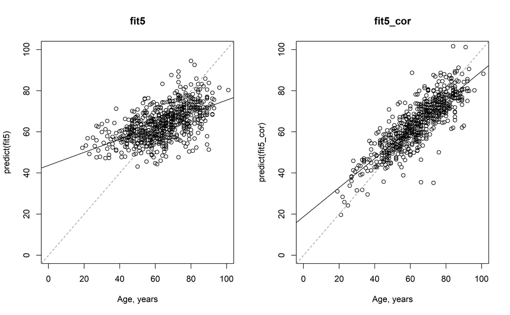

```r
# try:

# Visualise the fitted values against the age

par(mfrow = c(1,2))
plot(mdna_logodds$Age, predict(fit5), xlim = c(0, 100), ylim = c(0, 100), xlab = "Age, years", main = "fit5")
abline(lm(predict(fit5) ~ mdna_logodds$Age))
abline(0, 1, col = "gray55", lty = 2)
plot(mdna_logodds$Age, predict(fit5_cor), xlim = c(0, 100), ylim = c(0, 100), xlab = "Age, years", main = "fit5_cor")
abline(lm(predict(fit5_cor) ~ mdna_logodds$Age))
abline(0, 1, col = "gray55", lty = 2)
```

```r
par(mfrow = c(1, 1))


# check the correlation between the fitted values and age
cor(mdna_logodds$Age, predict(fit5))
```

```
## [1] 0.5632828
```

```r
cor(mdna_logodds$Age, predict(fit5_cor))
```

```
## [1] 0.8411689
```

# **Exercise 2:** Model with all variables

- Fit a model with all the variables available in the dataset (with the exception of the individual ID column) (hint: to facilitate you can add a ‘dot’ to the right side of the linear regression formula, as `lm(Age ~ .)`)
- Compare the outputs of the model with the previous ones?
  - Is the model better?
  - What are the AIC values? (hint: `extractAIC()`)
  - Can you improve the model?

```r
# fit the full model
fit_full <- lm(Age ~ ., data = mdna_logodds[, -1])

# summary and model diagnosis
summary(fit_full)
```

```
##
## Call:
## lm(formula = Age ~ ., data = mdna_logodds[, -1])
##
## Residuals:
##      Min       1Q   Median       3Q      Max
## -20.1390  -4.2501   0.1609   3.8995  27.4291
##
## Coefficients:
##                    Estimate Std. Error t value Pr(>|t|)
## (Intercept)        63.84299    8.70424   7.335 7.20e-13 ***
## GenderM            -2.14304    0.61373  -3.492 0.000515 ***
## EthnicityHispanic  -3.03768    0.94311  -3.221 0.001346 **
## cg17568996          3.71431    1.35263   2.746 0.006213 **
## cg02245378          1.16801    1.56288   0.747 0.455145
## cg14093936         -4.76925    2.67270  -1.784 0.074856 .
## cg15642326         -1.21806    1.46863  -0.829 0.407215
## cg24991452          0.71000    1.41807   0.501 0.616781
## cg04581377          0.48687    1.08231   0.450 0.652989
## cg01820374         -1.06315    2.06180  -0.516 0.606292
## cg06898923          3.35742    1.40765   2.385 0.017381 *
## cg11579069         -0.28816    2.08017  -0.139 0.889870
## cg19560758          4.34111    2.64630   1.640 0.101434
## cg17385448          1.56884    1.50302   1.044 0.297001
## cg03271907         -0.65164    0.82965  -0.785 0.432509
## cg04081402         -1.16240    1.79396  -0.648 0.517263
## cg26614073         -5.32649    1.65903  -3.211 0.001395 **
## cg17895149         -1.81704    2.01977  -0.900 0.368679
## cg22736354         11.74286    1.90165   6.175 1.22e-09 ***
## cg07549715          3.72195    2.09223   1.779 0.075753 .
## cg17592812         -0.43528    1.74254  -0.250 0.802828
## cg18463417          4.51946    2.21750   2.038 0.041977 *
## cg26832211         -2.28642    1.13901  -2.007 0.045155 *
## cg05724065          2.82073    1.93212   1.460 0.144835
## cg11091262          3.78871    1.43038   2.649 0.008291 **
## cg09809672         -6.75292    1.37110  -4.925 1.09e-06 ***
## cg11191337          2.06060    1.56522   1.316 0.188510
## cg10092957          1.26840    1.02357   1.239 0.215756
## cg04183425          2.85811    1.43103   1.997 0.046248 *
## cg02228185         -2.39602    0.70197  -3.413 0.000685 ***
```

[output cut: 14 more lines]

```
## cg06493994         15.64667    2.32934   6.717 4.29e-11 ***
## cg08090640          1.01144    1.63645   0.618 0.536763
## cg21801378          5.34502    0.92201   5.797 1.09e-08 ***
## cg02797569          0.05049    1.94930   0.026 0.979345
## cg03996822         -2.58648    1.52592  -1.695 0.090585 .
## cg18267374          6.59756    1.73430   3.804 0.000157 ***
## cg15037004         -5.03311    1.73955  -2.893 0.003949 **
## cg01511567         -1.39324    1.54066  -0.904 0.366191
## cg09817114         -1.87678    2.26216  -0.830 0.407071
## ---
## Signif. codes:  0 '***' 0.001 '**' 0.01 '*' 0.05 '.' 0.1 ' ' 1
##
## Residual standard error: 6.422 on 603 degrees of freedom
## Multiple R-squared:  0.8252, Adjusted R-squared:  0.8101
## F-statistic: 54.73 on 52 and 603 DF,  p-value: < 2.2e-16
```

**Questions:**

1. Are all the coefficients in the model needed?
2. Is there a way to automate the “selection” of variables to use in the model?

# **Exercise 3:** Stepwise regression

Let’s try to automate the process of variable selection. Since we already have a full model, we will also need an null model (regression with only the intercept).

- Fit a null model (hint: `lm(Age ~ 1)`)

```r
# fit a null model
fit_null <- lm(Age ~ 1, data = mdna_logodds)

# summary
summary(fit_null)
```

```
##
## Call:
## lm(formula = Age ~ 1, data = mdna_logodds)
##
## Residuals:
##     Min      1Q  Median      3Q     Max
## -45.035 -10.035   0.965  10.965  36.965
##
## Coefficients:
##             Estimate Std. Error t value Pr(>|t|)
## (Intercept)  64.0351     0.5754   111.3   <2e-16 ***
## ---
## Signif. codes:  0 '***' 0.001 '**' 0.01 '*' 0.05 '.' 0.1 ' ' 1
##
## Residual standard error: 14.74 on 655 degrees of freedom
```

**Question:** What is the formula for the null model? What is the value for $\beta_0$?

- Use the `step()` function (*{stats}* package), or the `stepAIC()` function (*{MASS}* package)
  - Look through the function’s help page to better understand how to use it
- Perform a stepwise selection
  1. Forward selection (hint1: `direction = "forward"`; hint2: in this process you start with the null model and add covariates)
  2. Backwards elimination (hint: `direction = "backward"`; hint2: here you start with the full model and remove covariates)
  3. Combination of both (hint: `direction = "both"`)
- Compare the models
  - AIC values
  - Do the models chose the same variables? The same number of variables?
  - Which one is better at predicting biological age?

```r
# forward selection
fit_step_forward <- stepAIC(fit_null, scope = formula(fit_full), direction = "forward", trace = FALSE)
summary(fit_step_forward)
```

```
##
## Call:
## lm(formula = Age ~ cg22736354 + cg15804973 + cg06493994 + cg09809672 +
##     cg21801378 + cg04474832 + Ethnicity + cg20645058 + cg17471102 +
##     cg18267374 + cg02228185 + cg22484793 + cg26614073 + cg18463417 +
##     Gender + cg15037004 + cg11091262 + cg04865575 + cg07737781 +
##     cg06898923 + cg06414605 + cg14093936 + cg17568996 + cg04183425 +
##     cg26832211 + cg01173291 + cg05724065 + cg19560758 + cg03996822 +
##     cg07549715 + cg07422345 + cg11191337, data = mdna_logodds)
##
## Residuals:
##      Min       1Q   Median       3Q      Max
## -18.4778  -4.0669   0.0912   3.8455  28.1476
##
## Coefficients:
##                   Estimate Std. Error t value Pr(>|t|)
## (Intercept)        63.7596     7.5567   8.437 2.27e-16 ***
## cg22736354         11.9546     1.8364   6.510 1.55e-10 ***
## cg15804973         -3.0616     1.2918  -2.370 0.018091 *
## cg06493994         15.4499     2.2627   6.828 2.05e-11 ***
## cg09809672         -7.0378     1.2846  -5.479 6.23e-08 ***
## cg21801378          5.2756     0.8751   6.029 2.83e-09 ***
## cg04474832         -9.6464     2.4258  -3.977 7.81e-05 ***
## EthnicityHispanic  -2.9253     0.7999  -3.657 0.000276 ***
## cg20645058          5.0419     1.8043   2.794 0.005360 **
## cg17471102         -6.0038     1.8939  -3.170 0.001598 **
## cg18267374          6.3539     1.6663   3.813 0.000151 ***
## cg02228185         -2.3847     0.6822  -3.496 0.000507 ***
## cg22484793          5.3601     2.0143   2.661 0.007993 **
## cg26614073         -5.5888     1.5738  -3.551 0.000412 ***
## cg18463417          4.2736     2.0078   2.128 0.033688 *
## GenderM            -1.9856     0.5656  -3.510 0.000480 ***
## cg15037004         -5.0205     1.6134  -3.112 0.001946 **
## cg11091262          4.2959     1.3472   3.189 0.001501 **
## cg04865575         -3.7758     1.7919  -2.107 0.035503 *
## cg07737781          3.3926     1.7678   1.919 0.055432 .
## cg06898923          3.3309     1.3585   2.452 0.014486 *
## cg06414605         -4.8130     1.9371  -2.485 0.013229 *
## cg14093936         -5.7703     2.5249  -2.285 0.022629 *
## cg17568996          3.0610     1.2578   2.433 0.015234 *
## cg04183425          2.9663     1.3248   2.239 0.025507 *
## cg26832211         -2.4359     1.0946  -2.226 0.026404 *
## cg01173291         -3.2853     1.8609  -1.765 0.077973 .
## cg05724065          3.2970     1.8317   1.800 0.072359 .
## cg19560758          3.6831     2.4091   1.529 0.126821
## cg03996822         -3.0823     1.4691  -2.098 0.036300 *
## cg07549715          3.3717     2.0021   1.684 0.092664 .
## cg07422345          2.2710     1.3608   1.669 0.095632 .
## cg11191337          2.1055     1.5043   1.400 0.162118
## ---
## Signif. codes:  0 '***' 0.001 '**' 0.01 '*' 0.05 '.' 0.1 ' ' 1
##
## Residual standard error: 6.382 on 623 degrees of freedom
## Multiple R-squared:  0.8216, Adjusted R-squared:  0.8125
## F-statistic: 89.68 on 32 and 623 DF,  p-value: < 2.2e-16
```

```r
# backward elimination
fit_step_backward <- stepAIC(fit_full, scope = formula(fit_full), direction = "backward", trace = FALSE)
summary(fit_step_backward)
```

```
##
## Call:
## lm(formula = Age ~ Gender + Ethnicity + cg17568996 + cg14093936 +
##     cg06898923 + cg19560758 + cg26614073 + cg22736354 + cg07549715 +
##     cg18463417 + cg26832211 + cg05724065 + cg11091262 + cg09809672 +
##     cg11191337 + cg04183425 + cg02228185 + cg06414605 + cg07422345 +
##     cg07737781 + cg20645058 + cg04474832 + cg15804973 + cg01173291 +
##     cg22484793 + cg17471102 + cg04865575 + cg06493994 + cg21801378 +
##     cg03996822 + cg18267374 + cg15037004, data = mdna_logodds[,
##     -1])
##
## Residuals:
##      Min       1Q   Median       3Q      Max
## -18.4778  -4.0669   0.0912   3.8455  28.1476
##
## Coefficients:
##                   Estimate Std. Error t value Pr(>|t|)
## (Intercept)        63.7596     7.5567   8.437 2.27e-16 ***
## GenderM            -1.9856     0.5656  -3.510 0.000480 ***
## EthnicityHispanic  -2.9253     0.7999  -3.657 0.000276 ***
## cg17568996          3.0610     1.2578   2.433 0.015234 *
## cg14093936         -5.7703     2.5249  -2.285 0.022629 *
## cg06898923          3.3309     1.3585   2.452 0.014486 *
## cg19560758          3.6831     2.4091   1.529 0.126821
## cg26614073         -5.5888     1.5738  -3.551 0.000412 ***
## cg22736354         11.9546     1.8364   6.510 1.55e-10 ***
## cg07549715          3.3717     2.0021   1.684 0.092664 .
## cg18463417          4.2736     2.0078   2.128 0.033688 *
## cg26832211         -2.4359     1.0946  -2.226 0.026404 *
## cg05724065          3.2970     1.8317   1.800 0.072359 .
## cg11091262          4.2959     1.3472   3.189 0.001501 **
## cg09809672         -7.0378     1.2846  -5.479 6.23e-08 ***
## cg11191337          2.1055     1.5043   1.400 0.162118
## cg04183425          2.9663     1.3248   2.239 0.025507 *
## cg02228185         -2.3847     0.6822  -3.496 0.000507 ***
## cg06414605         -4.8130     1.9371  -2.485 0.013229 *
## cg07422345          2.2710     1.3608   1.669 0.095632 .
## cg07737781          3.3926     1.7678   1.919 0.055432 .
## cg20645058          5.0419     1.8043   2.794 0.005360 **
## cg04474832         -9.6464     2.4258  -3.977 7.81e-05 ***
## cg15804973         -3.0616     1.2918  -2.370 0.018091 *
## cg01173291         -3.2853     1.8609  -1.765 0.077973 .
## cg22484793          5.3601     2.0143   2.661 0.007993 **
## cg17471102         -6.0038     1.8939  -3.170 0.001598 **
## cg04865575         -3.7758     1.7919  -2.107 0.035503 *
## cg06493994         15.4499     2.2627   6.828 2.05e-11 ***
## cg21801378          5.2756     0.8751   6.029 2.83e-09 ***
## cg03996822         -3.0823     1.4691  -2.098 0.036300 *
## cg18267374          6.3539     1.6663   3.813 0.000151 ***
## cg15037004         -5.0205     1.6134  -3.112 0.001946 **
## ---
## Signif. codes:  0 '***' 0.001 '**' 0.01 '*' 0.05 '.' 0.1 ' ' 1
##
## Residual standard error: 6.382 on 623 degrees of freedom
## Multiple R-squared:  0.8216, Adjusted R-squared:  0.8125
## F-statistic: 89.68 on 32 and 623 DF,  p-value: < 2.2e-16
```

```r
# using both methods iteratively
fit_step_both <- stepAIC(fit_null, scope = formula(fit_full), direction = "both", trace = FALSE)
summary(fit_step_both)
```

```
##
## Call:
## lm(formula = Age ~ cg22736354 + cg15804973 + cg06493994 + cg09809672 +
##     cg21801378 + cg04474832 + Ethnicity + cg20645058 + cg17471102 +
##     cg18267374 + cg02228185 + cg22484793 + cg26614073 + cg18463417 +
##     Gender + cg15037004 + cg11091262 + cg04865575 + cg07737781 +
##     cg06898923 + cg06414605 + cg14093936 + cg17568996 + cg04183425 +
##     cg26832211 + cg01173291 + cg05724065 + cg19560758 + cg03996822 +
##     cg07549715 + cg07422345 + cg11191337, data = mdna_logodds)
##
## Residuals:
##      Min       1Q   Median       3Q      Max
## -18.4778  -4.0669   0.0912   3.8455  28.1476
##
## Coefficients:
##                   Estimate Std. Error t value Pr(>|t|)
## (Intercept)        63.7596     7.5567   8.437 2.27e-16 ***
## cg22736354         11.9546     1.8364   6.510 1.55e-10 ***
## cg15804973         -3.0616     1.2918  -2.370 0.018091 *
## cg06493994         15.4499     2.2627   6.828 2.05e-11 ***
## cg09809672         -7.0378     1.2846  -5.479 6.23e-08 ***
## cg21801378          5.2756     0.8751   6.029 2.83e-09 ***
## cg04474832         -9.6464     2.4258  -3.977 7.81e-05 ***
## EthnicityHispanic  -2.9253     0.7999  -3.657 0.000276 ***
## cg20645058          5.0419     1.8043   2.794 0.005360 **
## cg17471102         -6.0038     1.8939  -3.170 0.001598 **
## cg18267374          6.3539     1.6663   3.813 0.000151 ***
## cg02228185         -2.3847     0.6822  -3.496 0.000507 ***
## cg22484793          5.3601     2.0143   2.661 0.007993 **
## cg26614073         -5.5888     1.5738  -3.551 0.000412 ***
## cg18463417          4.2736     2.0078   2.128 0.033688 *
## GenderM            -1.9856     0.5656  -3.510 0.000480 ***
## cg15037004         -5.0205     1.6134  -3.112 0.001946 **
## cg11091262          4.2959     1.3472   3.189 0.001501 **
## cg04865575         -3.7758     1.7919  -2.107 0.035503 *
## cg07737781          3.3926     1.7678   1.919 0.055432 .
## cg06898923          3.3309     1.3585   2.452 0.014486 *
## cg06414605         -4.8130     1.9371  -2.485 0.013229 *
## cg14093936         -5.7703     2.5249  -2.285 0.022629 *
## cg17568996          3.0610     1.2578   2.433 0.015234 *
## cg04183425          2.9663     1.3248   2.239 0.025507 *
## cg26832211         -2.4359     1.0946  -2.226 0.026404 *
## cg01173291         -3.2853     1.8609  -1.765 0.077973 .
## cg05724065          3.2970     1.8317   1.800 0.072359 .
## cg19560758          3.6831     2.4091   1.529 0.126821
## cg03996822         -3.0823     1.4691  -2.098 0.036300 *
## cg07549715          3.3717     2.0021   1.684 0.092664 .
## cg07422345          2.2710     1.3608   1.669 0.095632 .
## cg11191337          2.1055     1.5043   1.400 0.162118
## ---
## Signif. codes:  0 '***' 0.001 '**' 0.01 '*' 0.05 '.' 0.1 ' ' 1
##
## Residual standard error: 6.382 on 623 degrees of freedom
## Multiple R-squared:  0.8216, Adjusted R-squared:  0.8125
## F-statistic: 89.68 on 32 and 623 DF,  p-value: < 2.2e-16
```

```r
# compare results
length(coef(fit_step_forward)[-1])
```

```
## [1] 32
```

```r
length(coef(fit_step_backward)[-1])
```

```
## [1] 32
```

```r
length(coef(fit_step_both)[-1])
```

```
## [1] 32
```

```r
extractAIC(fit_step_forward)
```

```
## [1]   33.000 2463.856
```

```r
extractAIC(fit_step_backward)
```

```
## [1]   33.000 2463.856
```

```r
extractAIC(fit_step_both)
```

```
## [1]   33.000 2463.856
```

# Extending the analysis

```r
# does it improve with Gender?


# define empty data frame
gender_lm <- data.frame()

# run for loop
for(i in seq(vec_probe)) {

  fit_formula <- as.formula(paste0("Age ~ Gender + ", vec_probe[i]))
  fit <- lm(fit_formula, data = mdna_logodds)
  fit_summary <- summary(fit)

  out <- data.frame(coef = vec_probe[i],
                    genderM = fit_summary$coefficients[2,1],
                    genderM_p = fit_summary$coefficients[2,4],
                    estimate = fit_summary$coefficients[3,1],
                    estimate_p = fit_summary$coefficients[3,4],
                    r_rquared = fit_summary$r.squared,
                    r_rquared_adj = fit_summary$adj.r.squared,
                    aic = AIC(fit),
                    bic = BIC(fit)
                    )

  gender_lm <- rbind(gender_lm, out)
}
gender_lm
```

```
##          coef     genderM    genderM_p      estimate   estimate_p   r_rquared
## 1  cg17568996 -1.47799508 0.1957362588  -7.472233135 3.260983e-05 0.027400776
## 2  cg02245378 -1.00118426 0.3794621532  11.118382817 6.330024e-05 0.025523785
## 3  cg14093936 -2.23502388 0.0288853210 -42.766080086 2.617863e-37 0.221976230
## 4  cg15642326 -1.94088553 0.0879521396 -15.964010329 2.718694e-08 0.047520035
## 5  cg24991452 -1.16054783 0.2903053965 -14.831604031 8.825619e-16 0.095572194
## 6  cg04581377 -1.02242184 0.3739182557  -4.335223543 4.675299e-02 0.007365106
## 7  cg01820374 -0.35094936 0.7040785271 -43.537320203 5.462214e-65 0.359481250
## 8  cg06898923 -1.07735782 0.3505792551   0.132895740 9.631391e-01 0.001334586
## 9  cg11579069 -0.91378396 0.4276104035   7.335883104 3.927284e-02 0.007813433
## 10 cg19560758 -0.22495830 0.8166630706  43.398177158 3.185109e-51 0.294395605
## 11 cg17385448 -1.27247027 0.2714707805  -4.824114898 1.007049e-01 0.005446579
## 12 cg03271907 -1.19612688 0.2976930560   4.096377101 1.166954e-02 0.011018774
## 13 cg04081402 -3.38639394 0.0013885421 -27.380385943 1.590793e-31 0.189778757
## 14 cg26614073 -2.84871594 0.0043327388 -34.889966363 1.766944e-45 0.265341449
```

[output cut: 87 more lines]

```r
# does it improve with Ethnicity?


# define empty data frame
ethnicity_lm <- data.frame()

# run for loop
for(i in seq(vec_probe)) {

  fit_formula <- as.formula(paste0("Age ~ Ethnicity + ", vec_probe[i]))
  fit <- lm(fit_formula, data = mdna_logodds)
  fit_summary <- summary(fit)

  out <- data.frame(coef = vec_probe[i],
                    ethnicityHisp = fit_summary$coefficients[2,1],
                    ethnicityHisp_p = fit_summary$coefficients[2,4],
                    estimate = fit_summary$coefficients[3,1],
                    estimate_p = fit_summary$coefficients[3,4],
                    r_rquared = fit_summary$r.squared,
                    r_rquared_adj = fit_summary$adj.r.squared,
                    aic = AIC(fit),
                    bic = BIC(fit)
                    )

  ethnicity_lm <- rbind(ethnicity_lm, out)
}
ethnicity_lm
```

```
##          coef ethnicityHisp ethnicityHisp_p     estimate   estimate_p r_rquared
## 1  cg17568996    -14.190340    3.016457e-34  -2.12429963 1.953863e-01 0.2238527
## 2  cg02245378    -14.531725    1.798609e-38  11.12897486 5.503252e-06 0.2461008
## 3  cg14093936    -11.675468    1.777127e-28 -33.60132976 1.874556e-27 0.3504317
## 4  cg15642326    -13.890663    8.351356e-35 -10.41280367 4.542989e-05 0.2414374
## 5  cg24991452    -13.831228    1.500887e-23  -1.84098747 3.768249e-01 0.2227868
## 6  cg04581377    -14.449175    3.906008e-37  -3.02887144 1.161047e-01 0.2247949
## 7  cg01820374    -10.718540    1.450355e-29 -37.52357046 2.924987e-57 0.4730461
## 8  cg06898923    -14.716818    5.503989e-38   3.89308591 1.267483e-01 0.2246319
## 9  cg11579069    -14.424663    6.744872e-37   4.26712015 1.750325e-01 0.2240463
## 10 cg19560758    -11.282283    6.766729e-30  36.70066442 7.766384e-44 0.4209252
## 11 cg17385448    -14.737979    1.453888e-38  -6.99183392 6.770375e-03 0.2305519
## 12 cg03271907    -14.384161    1.936369e-36   1.70999526 2.368487e-01 0.2235228
## 13 cg04081402    -11.295977    2.355591e-23 -17.79089528 2.587298e-15 0.2929947
## 14 cg26614073    -11.964558    1.495136e-32 -29.07860272 5.666663e-39 0.4008171
```

[output cut: 87 more lines]

## `ifelse("I'm ahead of schedule", DO, SKIP)`

- Look for any potential influential points (hint: Cook’s distance)
- Would an interaction term further improve our the models?
- Problems of correlation? Multicollinearity?

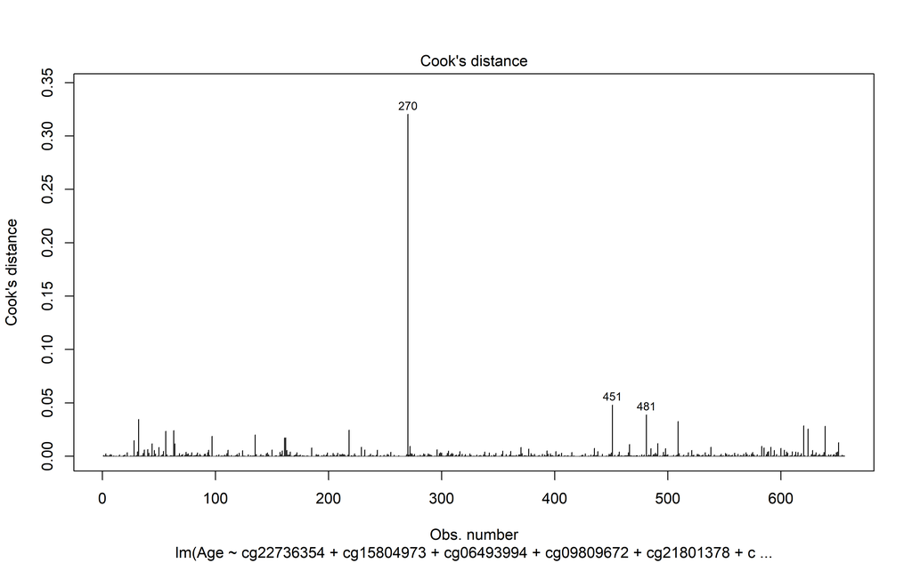

```r
plot(fit_step_both, which = 4)
```

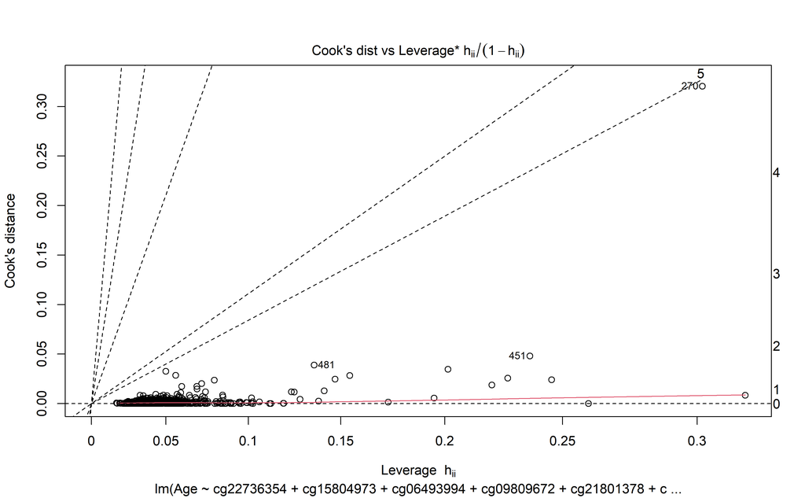

```r
plot(fit_step_both, which = 6)
```